# DaVinci Bi-modal integration: Adult Mouse Brain (DBiT-seq, RNA + ATAC)

# Overview

This notebook reproduces a **bi-modal (RNA + ATAC)** integration workflow on Adult DBiT-seq data using **DaVinci**.

1. **Cross-section integration within each modality** (RNA across sections; ATAC across sections)
2. **Cross-modality (Vertical) integration** across RNA and ATAC using library-size reweighting
3. **Clustering + optional spatial refinement**, followed by visualization and summary plots

## Setup

Load packages used by this analysis.

```r
library(DaVinci)
library(ggpubr)

# Working directory for this tutorial
setwd("~/For_Tutorial/Adult_DBiT-seq/")
```

## Load the data

We load two sections (V1 and V2), each with an RNA and an ATAC assay stored as separate RDS files. Each RDS is expected to contain: - `mat`: a feature-by-spot matrix (raw counts) - `coor`: a spot-by-(x,y) coordinate matrix

```r
data.dir <- "~/For_Tutorial/Adult_DBiT-seq/data/"

# V1
input.V1 <- readRDS(paste0(data.dir, "V1/RNA.RDS"))
gene.exp.V1 <- input.V1$mat
coor.V1 <- input.V1$coor

input.V1 <- readRDS(paste0(data.dir, "V1/ATAC.RDS"))
input.atac.V1 <- input.V1$mat
coor.atac.V1 <- input.V1$coor

# V2
input.V2 <- readRDS(paste0(data.dir, "V2/RNA.RDS"))
gene.exp.V2 <- input.V2$mat
coor.V2 <- input.V2$coor

input.V2 <- readRDS(paste0(data.dir, "V2/ATAC.RDS"))
input.atac.V2 <- input.V2$mat
coor.atac.V2 <- input.V2$coor
```

# Part I — Horizontal integration (RNA)

## Preprocess RNA for each section

We preprocess each RNA matrix using a spatial graph (Triangular mesh) and filtering threshold `frac.thr`. The output `fin.*` objects provide: - `mat`: processed data matrix used for decomposition/integration - `L`: spatial structure (graph/Laplacian) - `coor`: cleaned/aligned coordinates

```r
fin.V1 <- preprocess(
  gene.exp.V1,
  coor.V1,
  type = "rna",
  graph.opt = "Tri.mesh",
  frac.thr = 0.95
)

fin.V2 <- preprocess(
  gene.exp.V2,
  coor.V2,
  type = "rna",
  graph.opt = "Tri.mesh",
  frac.thr = 0.95
)

Y.list <- list(fin.V1$mat, fin.V2$mat)
L.list <- list(fin.V1$L, fin.V2$L)
coor.list <- list(fin.V1$coor, fin.V2$coor)

dataset.opts <- c("V1", "V2")
names(coor.list) <- dataset.opts
```

## Assemble RNA integration across sections

`Horizontal.Integration.Assemble()` searches across a candidate set of latent dimensions (`k.arg.list`), selecting robust latent variables per section and integrating them across sections.

```r
RNA.res <- Horizontal.Integration.Assemble(
  dataset.opts = dataset.opts,
  Y.list  = Y.list,
  L.list  = L.list,
  coor.list = coor.list,
  k.arg.list = c(4, 6, 8, 10, 11, 12, 13, 15, 16, 18, 20, 22, 24)
)
```

## Cluster using RNA only (mclust)

We can cluster the integrated RNA representation using Gaussian mixture modeling (`mclust`), through a helper function `swk()` (defined in the sourced scripts).

```r
cluster.RNA <- swk(
  RNA.res$mat,
  method = "mclust",
  L2norm = TRUE,
  mclust.model = "EEE",
  mclust.num = 10,
  random.seed = 1
)
```

```
## [1] "Number of unique clusters is 10"
```

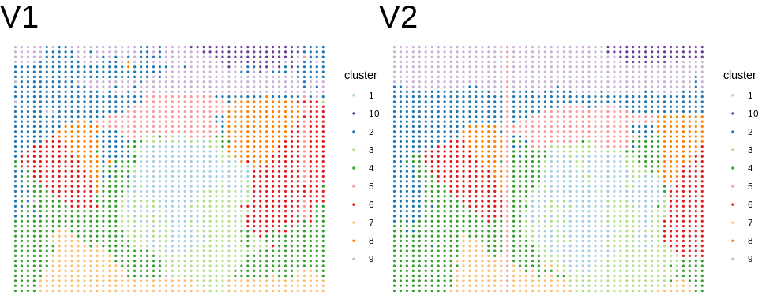

```r
plot.list <- scatter.DiscretePlot.list(
  cluster.RNA,
  coor.list,
  mat.slice.id = RNA.res$mat.slice.id,
  dataset.opts,
  pt.size = 0.5,
  title.size = 30,
  orientation = "-yx",
  ratio = NULL,
  return.obj = TRUE
)

ggarrange(plotlist = plot.list, nrow = 1)
```

# Part II — Horizontal integration (ATAC)

## Preprocess ATAC for each section

This chunk preprocesses the ATAC matrices. In the original script, `type = "rna"` is used for ATAC inputs. If your preprocessing expects ATAC-specific normalization (e.g., LSI), you may want to switch `type="atac"` and add LSI parameters. Here we keep your original behavior for fidelity.

```r
fin.atac.V1 <- preprocess(
  input.atac.V1,
  coor.V1,
  type = "rna",
  graph.opt = "Tri.mesh",
  frac.thr = 0.95
)

fin.atac.V2 <- preprocess(
  input.atac.V2,
  coor.V2,
  type = "rna",
  graph.opt = "Tri.mesh",
  frac.thr = 0.95
)

Y.list <- list(fin.atac.V1$mat, fin.atac.V2$mat)
L.list <- list(fin.atac.V1$L, fin.atac.V2$L)
coor.list <- list(fin.atac.V1$coor, fin.atac.V2$coor)
names(coor.list) <- dataset.opts
```

## Assemble ATAC integration across sections

```r
ATAC.res <- Horizontal.Integration.Assemble(
  dataset.opts = dataset.opts,
  Y.list  = Y.list,
  L.list  = L.list,
  coor.list = coor.list,
  k.arg.list = c(4, 6, 8, 10, 11, 12, 13, 15, 16, 18, 20, 22, 24)
)
```

# Part III — Cross-modality integration (RNA + ATAC)

## Compute library sizes (for reweighting)

We compute per-spot library sizes for RNA and ATAC, and attach names that uniquely identify each spot using the convention `V1@<spot>` / `V2@<spot>`.

```r
library.size.RNA <- c(Matrix::colSums(gene.exp.V1), Matrix::colSums(gene.exp.V2))
library.size.ATAC <- c(Matrix::colSums(input.atac.V1), Matrix::colSums(input.atac.V2))

library.names.RNA <- c(paste0("V1@", colnames(gene.exp.V1)), paste0("V2@", colnames(gene.exp.V2)))
library.names.ATAC <- c(paste0("V1@", colnames(input.atac.V1)), paste0("V2@", colnames(input.atac.V2)))

#Alignment checks:
print(all(library.names.RNA == library.names.ATAC))
```

```
## [1] TRUE
```

```r
names(library.size.RNA) <- library.names.RNA
names(library.size.ATAC) <- library.names.ATAC
```

## Align spots and run BiModalIntegration

We ensure spots have unique, matching identifiers across modalities before integration.

```r
mat.RNA <- RNA.res$mat
rownames(mat.RNA) <- paste0(RNA.res$mat.slice.id, "@", rownames(mat.RNA))

mat.ATAC <- ATAC.res$mat
rownames(mat.ATAC) <- paste0(ATAC.res$mat.slice.id, "@", rownames(mat.ATAC))

# Sanity checks: match ordering across modalities and library-size vectors
all(rownames(mat.RNA) == rownames(mat.ATAC))
```

```
## [1] TRUE
```

```r
all(rownames(mat.RNA) == names(library.size.RNA))
```

```
## [1] TRUE
```

```r
integration.res <- BiModalIntegration(
  modal.1 = mat.RNA,
  modal.2 = mat.ATAC,
  library.size.1 = library.size.RNA,
  library.size.2 = library.size.ATAC,
  library.type.1 = "rna",
  library.type.2 = "atac",
  n_neighbors = 40,
  n_neighbors_large = 50,
  L2norm = "column"
)
```

```
## [1] "Adjust the weights by library size."
```

# Part IV — Visualization and clustering after bi-modal integration

## Visualize RNA modality weights

`integration.res$weight.1` provides per-spot weights indicating the contribution of RNA in the integrated representation. We plot these weights spatially for each section.

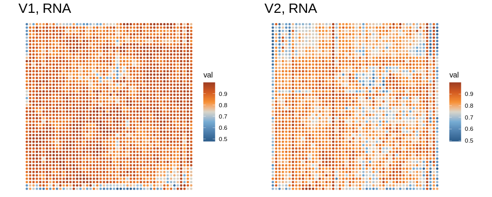

```r
plot.list <- list()

mat.slice.id <- unlist(lapply(strsplit(names(integration.res$weight.1), "@"), function(x){x[1]}))

for (ii in seq_along(dataset.opts)) {
  coor <- coor.list[[ii]]

  LV.to_plot <- integration.res$weight.1
  LV.to_plot <- LV.to_plot[mat.slice.id == dataset.opts[ii]]

  # ensure names aligned to the coordinate rownames
  LV.to_plot <- LV.to_plot[paste0(dataset.opts[ii], "@", rownames(coor))]

  plot.list[[ii]] <- scatter.FeaturePlot(
    coor,
    LVs = LV.to_plot,
    plot.all = FALSE,
    pt.size = 1,
    orientation = "-yx"
  ) +
    ggtitle(paste0(dataset.opts[ii], ", RNA")) +
    theme(plot.title = element_text(size = 20)) +
    coord_fixed(ratio = 1)
}

ggarrange(plotlist = plot.list, nrow = 1)
```

## Cluster using integrated graph (vertical integration)

We cluster using the integrated SNN graph (`integration.res$snn.mat`) via `leiden_adaptive()`. We then smooth labels within each section using a local spatial refinement step.

```r
partition <- leiden_adaptive(
  integration.res$snn.mat,
  num.of.cluster = 10,
  resolution.start = 0.4,
  adaptive.size = 2,
  method = "louvain"
)
```

```
## 0.6 0.4 0.8
```

```
## 0.7 0.6 0.8
```

```
## 0.75 0.7 0.8
```

```
## 0.775 0.75 0.8
```

```r
partition <- as.character(partition)
names(partition) <- rownames(mat.RNA)

# Local smoothing / refinement within each section
partition.smooth <- partition

for (ii in seq_along(dataset.opts)) {
  subpart.index <- which(mat.slice.id == dataset.opts[ii])
  p.part <- partition[subpart.index]

  coor <- as.matrix(coor.list[[ii]])
  rownames(coor) <- paste0(dataset.opts[ii], "@", rownames(coor))

  p.part <- DaVinci:::refinement(
    p.part,
    coor[names(p.part), ],
    neighbor.option = "KNN",
    neighbor.arg = 8,
    tasks = "discrete"
  )

  partition.smooth[subpart.index] <- p.part
}
```

## Visualize refined clusters

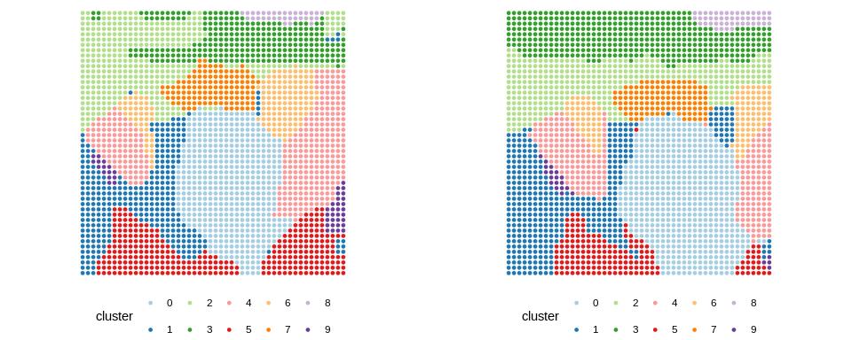

```r
par.to_plot <- partition.smooth
plot.list <- list()

for (ii in seq_along(dataset.opts)) {
  coor <- coor.list[[ii]]
  rownames(coor) <- paste0(dataset.opts[ii], "@", rownames(coor))

  pp <- par.to_plot[mat.slice.id == dataset.opts[ii]]
  partition.sub <- pp[rownames(coor)]

  plot.list[[ii]] <- scatter.DiscretePlot(
    coor,
    partition.sub,
    pt.size = 1,
    orientation = "-yx"
  ) +
    colorPalette(unique(par.to_plot), fill = FALSE) +
    theme(plot.title = element_text(size = 20)) +
    coord_fixed(ratio = 1) +
    theme(legend.position = "bottom")
}

ggarrange(plotlist = plot.list, nrow = 1)
```

## Compare modality weights across niches

Finally, we summarize modality weights by niche/cluster using violin plots. This shows how RNA vs ATAC contributions vary across discovered niches.

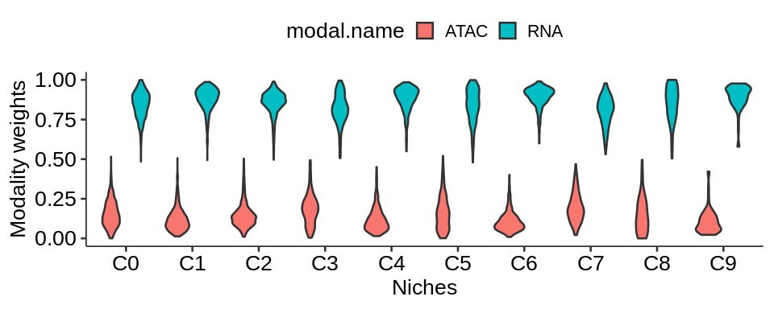

```r
weight <- c(integration.res$weight.1, integration.res$weight.2)
grp <- c(paste0("C", par.to_plot), paste0("C", par.to_plot))
modal.name <- c(rep("RNA", length(par.to_plot)), rep("ATAC", length(par.to_plot)))

to_plot <- data.frame(
  weight = weight,
  grp = grp,
  modal.name = modal.name,
  slice = mat.slice.id
)

ggplot(to_plot, aes(x = grp, y = weight, fill = modal.name)) +
  geom_violin() +
  theme_pubr(base_size = 20) +
  xlab("Niches") +
  ylab("Modality weights")
```